# Визуализация данных с помощью ggplot2, часть 1

## Другие эстетики

У каждого геометрического объекта есть свой набор эстетик, которые можно использовать для визуализации данных. Доступные варианты можно посмотреть в справке - `?geom_point`.

Например, для точек можно использовать следующие эстетики:

- положение (`x`, `y`),
- прозрачность (`alpha`),
- цвет (`colour`),
- фигура (`shape`),
- размер (`size`), и [др.](http://ggplot2.tidyverse.org/reference/#section-aesthetics)

Используем дополнительные эстетики, чтобы отобразить более сложную зависимость между переменными в наборе данных:

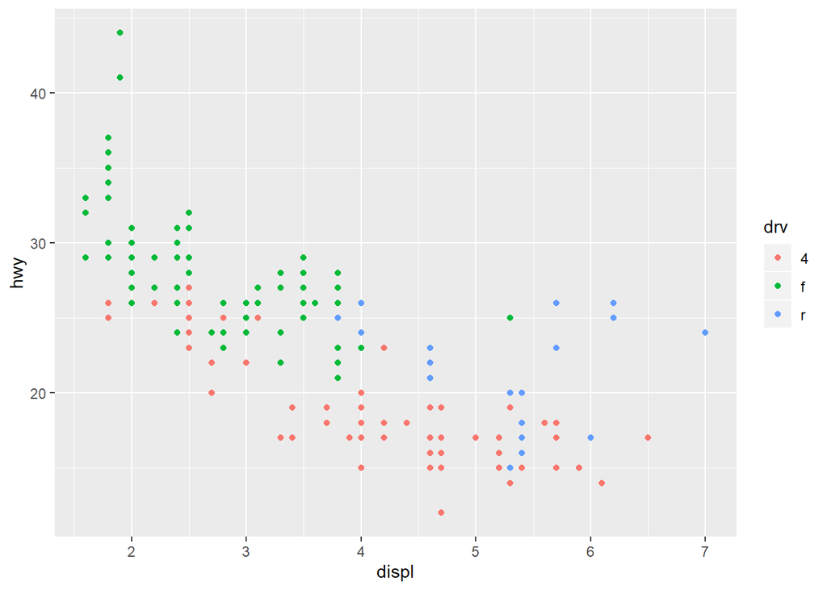

```r
ggplot(data = mpg) +
  geom_point(mapping = aes(x = displ, y = hwy,
                           colour = drv))
```

Связав тип привода `drv` с цветом, мы можем видеть более сложные зависимости. Например, что среди машин с объемом двигателя до 4 литров почти нет заднеприводных (`drv = 'r'`), или что при равном объеме двигателя полноприводные автомобили (`drv = '4'`) имеют меньший пробег на 1 галлоне топлива.

Вы можете подобрать любые сочетания эстетик для визуализации своих данных, однако стоит помнить о том, что сложность этих эстетик для восприятия разная. Человеку легче всего сравнивать расположение и линейные размеры объектов. А оттенки цвета люди различают плохо. Поэтому стоит помнить правило:

> Самые важные переменные следует связывать с эстетиками положения.

Эстетики можно условно разделить на два вида: **количественные**, пригодные для отображения количественных данных и **качественные**, пригодные для отображения категорий.

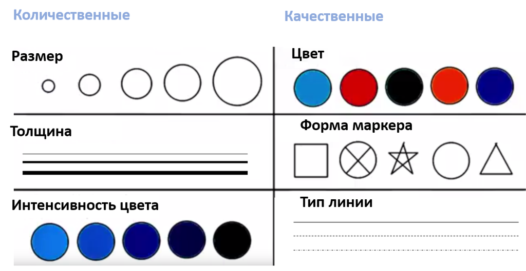

Количественные и качественные эстетики

В `gglot2` вы можете связывать данные с какими угодно эстетиками, однако если, например связать категориальную переменную (фактор) с количественной эстетикой (размер), то вы получите предупреждение. Цвет можно связывать как с количественными, так и с категориальными переменными, при этом будет выбрана подходящая цветовая шкала.

### Упражнение: связывание данных

В этом упражнении вы будете работать с набором данных о характеристиках и стоимости бриллиантов.

```r
data(diamonds)
head(diamonds)
```

```
## # A tibble: 6 x 10
##   carat cut       color clarity depth table price     x     y     z
##   <dbl> <ord>     <ord> <ord>   <dbl> <dbl> <int> <dbl> <dbl> <dbl>
## 1 0.23  Ideal     E     SI2      61.5    55   326  3.95  3.98  2.43
## 2 0.21  Premium   E     SI1      59.8    61   326  3.89  3.84  2.31
## 3 0.23  Good      E     VS1      56.9    65   327  4.05  4.07  2.31
## 4 0.290 Premium   I     VS2      62.4    58   334  4.2   4.23  2.63
## 5 0.31  Good      J     SI2      63.3    58   335  4.34  4.35  2.75
## 6 0.24  Very Good J     VVS2     62.8    57   336  3.94  3.96  2.48
```

С описанием набора можно познакомиться в справке: `?diamonds`.

Ваша задача - повторить визуализацию, показанную на рисунке.

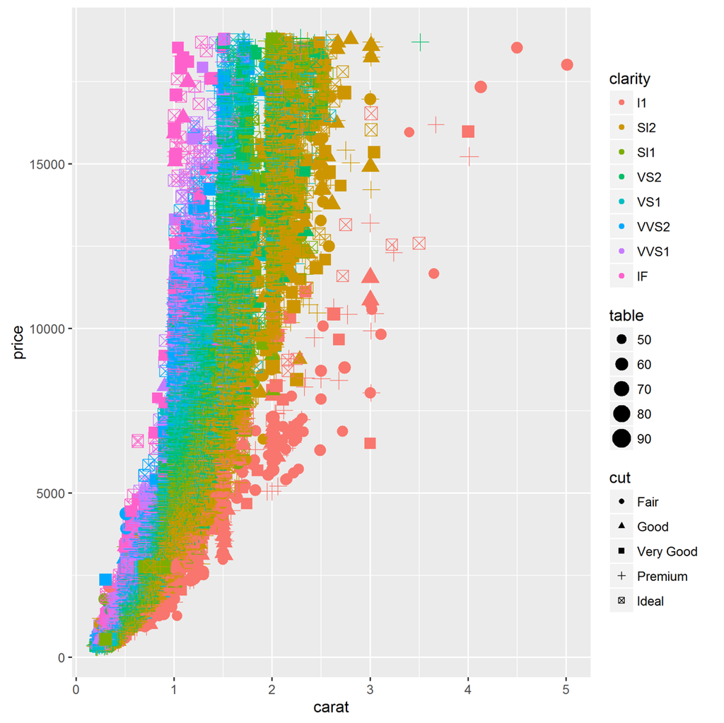

Визуализация зависимости цены бриллианта от его характеристик

**Совет:** вы можете открыть график в новом окне, кликнув по ссылке на него с нажатой клавшией `Shift`. Если RStudio жалуется на отсутствующий файл, - выполните команду меню: `Session/Set Working Directory/To Source File Location`, чтобы установить в качестве рабочей директории папку, в которой находится данный блокнот.

```r
# Раскомментируйте и допишите этот код:

#ggplot(data = ___) +
#  geom_point(mapping = aes(x = ____,
#                           y = ____,
#                           ______))
```